# MVP 2

Advanced Geocomputation

Matt Braaksma

University of Minnesota

October 29, 2024

## Overview

- Deforestation and cropland expansion are global problems, impacting greenhouse gas emissions, biodiversity, and more.
- Land conversion is strongly influenced by land supply elasticities.
  - How responsive is land supply (i.e., land expansion) to changes in prices?
  - Land supply elasticity refers to the percentage change in cropland resulting from a one percent increase in land rents for agriculture (relative to alternative uses).

## Overview

- However, due to a lack of price data in developing countries, these elasticities must be estimated.
  - Villoria & Liu (2018) estimate gridded land supply elasticities based on market access and land suitability factors.

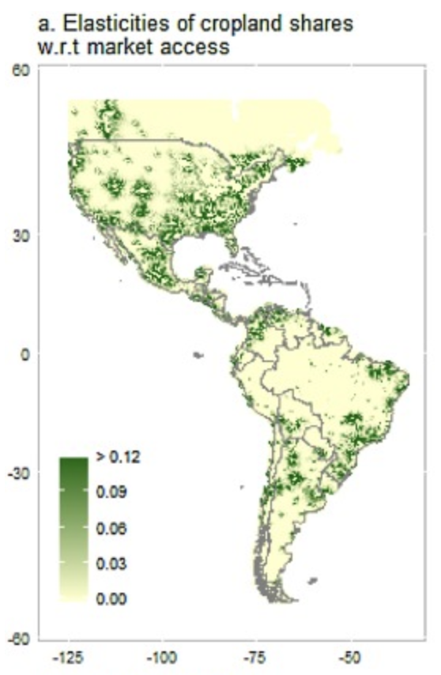

## MVP 2 Question

> How would predictions from a machine learning approach differ from econometric predictions?

## Next Steps

1. Gather data used in Villoria & Liu (2018)
   - Includes potential vegetation types (5 categories), soil fertility constraints (scale of 0-8), precipitation (mm/year), elevation (meters), soil pH (scale of 0-14), soil carbon (1m depth, kg-C/m²), temperature (°C), market access (index), area equipped for irrigation (% of grid cell), built-up land (% of grid cell), protected areas (binary 0-1), and agro-ecological zones (GTAP classification).
2. Replicate estimates from Villoria & Liu (2018)
3. Use `torchgeo` to predict elasticities
4. Compare predictions between methods